# Comparison of ASER, NAS, and IHDS

This notebook performs calculations and creates graphs for the section “Comparison of ASER, NAS, and IHDS” in the paper “Assessing the Assessments: Taking Stock of Learning Outcomes Data in India.”

Others who would like to run this notebook locally will need to:

1. Install the relevant R packages
2. Download the stata version of the individual level dataset from IHDS round 2. This dataset can be downloaded from [this page](https://www.icpsr.umich.edu/web/ICPSR/studies/36151?q=india+human+development+survey&searchSource=icpsr-landing#). The name of the dataset should be “36151-0001-Data.dta”.
3. Change the paths in the setup chunk

```r
library(tidyverse); library(haven); library(survey); library(ggrepel); library(broom); library(ICC)
```

```r
ihds_ind_dir <- "C:/Users/dougj/Documents/Data/IHDS/IHDS 2012/DS0001"
figures <- "C:/Users/dougj/Dropbox/Education in India/Original research/aservnas/figures"
```

# 1 Graphs of state rankings on ASER vs NAS

```r
# import ASER and NAS data
aser_nas <- read_csv("https://raw.githubusercontent.com/dougj892/public-datasets/master/ASER%202018%20and%20NAS%202017%20govt%20school%20grade%203%20reading.csv")
```

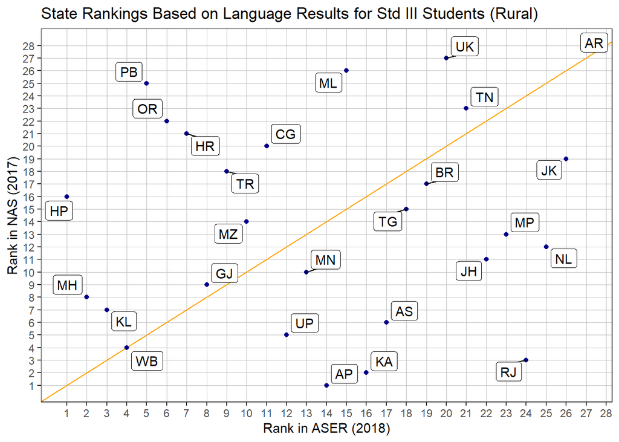

```r
# Create graph
ggplot(data = aser_nas,aes(x=aser_rank,y=nas_rank,label= state_abbr)) +
  geom_abline(intercept = 0, slope = 1, color="orange")  +
  geom_point(color="darkblue")  +
  theme_bw() +
  labs(title="State Rankings Based on Language Results for Std III Students (Rural)", x = "Rank in ASER (2018)", y = "Rank in NAS (2017)") +
   scale_y_continuous(breaks=c(1:28)) + scale_x_continuous(breaks=c(1:28))  + theme(panel.grid.minor = element_blank(), panel.grid.major = element_line(colour = "gray",size=0.1)) +
  geom_label_repel()
```

```r
# Save graph
ggsave("aser_nas_lang_ranking.png", width = 9, height = 6 , path = figures)
```

# 2 ASER and NAS vs NSDP

```r
# Import NSDP data
nsdp <- read_csv("https://raw.githubusercontent.com/dougj892/public-datasets/master/state%20GDP%20per%20capita.csv")
# Merge NSDP data with ASER and NAS data
aser_nas_nsdp <- aser_nas %>% left_join(nsdp, by = "State")

# Check that there are no states which didn't match
print(paste("Number of unmatched states", sum(is.na(aser_nas_nsdp$`NSDP per capita`))))
```

```
## [1] "Number of unmatched states 0"
```

```r
# Create a ranking for NSDP
aser_nas_nsdp$gdp_rank <- NA
aser_nas_nsdp$gdp_rank[order(aser_nas_nsdp$`NSDP per capita`, decreasing = TRUE)] <- 1:nrow(aser_nas_nsdp)

# Calculate pairwise correlations for the 3 datasets
temp <- aser_nas_nsdp %>% select(ASER_2018, 'NSDP per capita', NAS)
print("Pearson (regular) correlation:")
```

```
## [1] "Pearson (regular) correlation:"
```

```r
cor(temp, method = "pearson", use = "pairwise.complete.obs")
```

```
##                 ASER_2018 NSDP per capita       NAS
## ASER_2018       1.0000000       0.4154964 0.1872901
## NSDP per capita 0.4154964       1.0000000 0.0515147
## NAS             0.1872901       0.0515147 1.0000000
```

```r
print("Spearman (rank) correlation")
```

```
## [1] "Spearman (rank) correlation"
```

```r
cor(temp, method = "spearman", use = "pairwise.complete.obs")
```

```
##                 ASER_2018 NSDP per capita       NAS
## ASER_2018       1.0000000       0.3758205 0.1267176
## NSDP per capita 0.3758205       1.0000000 0.1382236
## NAS             0.1267176       0.1382236 1.0000000
```

```r
# Calculate correlations with p-values for null rho = 0
cor.test(temp$ASER_2018,temp$`NSDP per capita`, use = "pairwise.complete.obs", method = "pearson")
```

```
##
##  Pearson's product-moment correlation
##
## data:  temp$ASER_2018 and temp$`NSDP per capita`
## t = 2.284, df = 25, p-value = 0.03113
## alternative hypothesis: true correlation is not equal to 0
## 95 percent confidence interval:
##  0.04213542 0.68703188
## sample estimates:
##       cor
## 0.4154964
```

```r
cor.test(temp$ASER_2018,temp$`NSDP per capita`, use = "pairwise.complete.obs", method = "spearman")
```

```
##
##  Spearman's rank correlation rho
##
## data:  temp$ASER_2018 and temp$`NSDP per capita`
## S = 2044.8, p-value = 0.05337
## alternative hypothesis: true rho is not equal to 0
## sample estimates:
##       rho
## 0.3758205
```

```r
cor.test(temp$NAS,temp$`NSDP per capita`, use = "pairwise.complete.obs", method = "pearson")
```

```
##
##  Pearson's product-moment correlation
##
## data:  temp$NAS and temp$`NSDP per capita`
## t = 0.26302, df = 26, p-value = 0.7946
## alternative hypothesis: true correlation is not equal to 0
## 95 percent confidence interval:
##  -0.3278634  0.4165853
## sample estimates:
##       cor
## 0.0515147
```

```r
cor.test(temp$NAS,temp$`NSDP per capita`, use = "pairwise.complete.obs", method = "spearman")
```

```
##
##  Spearman's rank correlation rho
##
## data:  temp$NAS and temp$`NSDP per capita`
## S = 3148.9, p-value = 0.483
## alternative hypothesis: true rho is not equal to 0
## sample estimates:
##       rho
## 0.1382236
```

# 3 Correlation between ASER grade 3 reading and math

```r
aser_trends <- read_csv("https://raw.githubusercontent.com/dougj892/public-datasets/master/ASER%20trends%20over%20time.csv")
corrs <- aser_trends %>%
  group_by(year) %>%
  summarise(pearson = cor(std3_read_std1_all, std3_subtract_all, use="pairwise.complete.obs", method="pearson"),
            spearman = cor(std3_read_std1_all, std3_subtract_all, use="pairwise.complete.obs", method="spearman"))
corrs %>% summarise_all(mean, na.rm = TRUE)
```

```
## # A tibble: 1 x 3
##    year pearson spearman
##   <dbl>   <dbl>    <dbl>
## 1 2011.   0.819    0.798
```

# 4 Calculate IHDS scores by state.

Calculate percentage of students with ASER (TA8B) == 4 (i.e. can read std 2 level text) for rural (URBAN2011 == 0) govt school (CS4 ==2) or private aided (CS4 == 3) students in grades (TA4) 2 to 5 (there are too few students if we restrict only to grade 3) by state. *warning: this code takes a long time*

```r
ind_file <- file.path(ihds_ind_dir, "36151-0001-Data.dta")
# read in just those variables that i need
# this is much faster than reading in everything and then selecting
ihds <- read_dta(ind_file, col_select = c(STATEID, DISTID, PSUID, HHID, HHSPLITID, PERSONID, IDPSU, WT, RO3, RO7, RO5, URBAN2011, starts_with("CS"), starts_with("TA"), starts_with("ED")))
ihds <- ihds %>% mutate(psu_expanded = paste(STATEID, DISTID, PSUID, sep ="-"), hh_expanded = paste(STATEID, DISTID, PSUID, HHID, HHSPLITID, sep ="-"))

# confirm that TA4 (class) is not NA if TA8B is not NA --> there are only 38 instances when TA8B is not NA but TA4 is NA
ihds %>% filter(!is.na(TA8B)) %>% count(TA4)
```

```
## # A tibble: 11 x 2
##      TA4     n
##    <dbl> <int>
##  1     0   185
##  2     1  1205
##  3     2  1981
##  4     3  2571
##  5     4  2613
##  6     5  2001
##  7     6   949
##  8     7   242
##  9     8    57
## 10     9    15
## 11    NA    38
```

```r
# drop the one row with missing values for weights
ihds <- ihds %>% filter(!is.na(WT))

# create variable for ASER at level 4
ihds <- ihds %>% mutate(ASER4 = (TA8B ==4)) %>% mutate(State = as_factor(STATEID))
```

```r
# use the survey package to set the survey design.  I will use the ihds_svy object to calculate CIs
ihds_svy <- svydesign(id =~ psu_expanded + hh_expanded, weights =~ WT, data = ihds)

# use statsby to get the % of selected kids who achieve level 4 on ASER reading by state
# note that I am not sure if subsetting within statsby is kosher, but the standard errors should be ok
# more or less ok regardless
ihds_scores <- svyby(~ASER4, ~State, subset(ihds_svy, !is.na(TA8B) & (CS4 == 2 | CS4 == 3) & (TA4 >= 2 & TA4 <= 5) & (URBAN2011 == 0)), svymean, na.rm=TRUE)

# convert to a tibble
ihds_scores <- as.tibble(ihds_scores) %>% select(State, ASER4TRUE, se.ASER4TRUE) %>% rename(ihds = ASER4TRUE, ihds_se = se.ASER4TRUE)
# Unsure, but I think this gets rid of the space and number at the end of the state name
ihds_scores$State <- sub("...$", "", ihds_scores$State)

# replace the standard errors with NA is SE == 0
ihds_scores$ihds[ihds_scores$ihds_se == 0] <- NA

# replace Orissa with Odisha in state
ihds_scores$State[ihds_scores$State == "Orissa"] <- "Odisha"
ihds_scores$ihds <- round(ihds_scores$ihds, 3)*100
```

# 5 Correlation between IHDS and ASER / NAS

```r
scores <- aser_nas %>% select(State, ASER_2018, NAS) %>%
  full_join(ihds_scores, by = "State")

# drop if IHDS_ASER is NA
# scores <- scores %>% filter(!is.na(IHDS_ASER)) %>% arrange(ASER) %>% select(State, ASER, IHDS_ASER, NAS, obs)

# calculate correlation matrix --> while there are a few outliers, overall the ASER data and IHDS data match Ok
temp <- scores %>% select(ASER_2018, ihds, NAS)
cor(temp, method = "pearson", use = "pairwise.complete.obs")
```

```
##           ASER_2018        ihds         NAS
## ASER_2018 1.0000000 0.617984954 0.187290066
## ihds      0.6179850 1.000000000 0.003204316
## NAS       0.1872901 0.003204316 1.000000000
```

```r
cor(temp, method = "spearman", use = "pairwise.complete.obs")
```

```
##           ASER_2018        ihds         NAS
## ASER_2018 1.0000000  0.60152502  0.12671756
## ihds      0.6015250  1.00000000 -0.03106467
## NAS       0.1267176 -0.03106467  1.00000000
```

```r
# Same as above, but with p-values
cor.test(temp$NAS,temp$ihds, use = "pairwise.complete.obs", method = "pearson")
```

```
##
##  Pearson's product-moment correlation
##
## data:  temp$NAS and temp$ihds
## t = 0.01433, df = 20, p-value = 0.9887
## alternative hypothesis: true correlation is not equal to 0
## 95 percent confidence interval:
##  -0.4189701  0.4242396
## sample estimates:
##         cor
## 0.003204316
```

```r
cor.test(temp$ASER_2018,temp$ihds, use = "pairwise.complete.obs", method = "pearson")
```

```
##
##  Pearson's product-moment correlation
##
## data:  temp$ASER_2018 and temp$ihds
## t = 3.5153, df = 20, p-value = 0.002176
## alternative hypothesis: true correlation is not equal to 0
## 95 percent confidence interval:
##  0.2655702 0.8247157
## sample estimates:
##      cor
## 0.617985
```

```r
cor.test(temp$NAS,temp$ASER_2018, use = "pairwise.complete.obs", method = "pearson")
```

```
##
##  Pearson's product-moment correlation
##
## data:  temp$NAS and temp$ASER_2018
## t = 0.95332, df = 25, p-value = 0.3496
## alternative hypothesis: true correlation is not equal to 0
## 95 percent confidence interval:
##  -0.2074917  0.5296102
## sample estimates:
##       cor
## 0.1872901
```

```r
cor.test(temp$NAS,temp$ihds, use = "pairwise.complete.obs", method = "spearman")
```

```
##
##  Spearman's rank correlation rho
##
## data:  temp$NAS and temp$ihds
## S = 1826, p-value = 0.8908
## alternative hypothesis: true rho is not equal to 0
## sample estimates:
##         rho
## -0.03106467
```

```r
cor.test(temp$ASER_2018,temp$ihds, use = "pairwise.complete.obs", method = "spearman")
```

```
##
##  Spearman's rank correlation rho
##
## data:  temp$ASER_2018 and temp$ihds
## S = 705.7, p-value = 0.003063
## alternative hypothesis: true rho is not equal to 0
## sample estimates:
##      rho
## 0.601525
```

```r
cor.test(temp$NAS,temp$ASER_2018, use = "pairwise.complete.obs", method = "spearman")
```

```
##
##  Spearman's rank correlation rho
##
## data:  temp$NAS and temp$ASER_2018
## S = 2860.9, p-value = 0.5288
## alternative hypothesis: true rho is not equal to 0
## sample estimates:
##       rho
## 0.1267176
```

# 6 Calculate ASER ICC

Calculate ASER ICC using the ICCest function from the ICC package as well manually using the output from the ANOVA table. (Note that the manual method assumes constant number of children per village which is not accurate but yields a similar result.)

```r
# Calculate ICC
icc_df <- ihds %>%
  filter(!is.na(TA8B) & (TA4 >= 2 & TA4 <= 5) & (URBAN2011 == 0))

ICCest(x = psu_expanded, y = TA8B, data = icc_df)
```

```
## $ICC
## [1] 0.182186
##
## $LowerCI
## [1] 0.1582673
##
## $UpperCI
## [1] 0.2073873
##
## $N
## [1] 1295
##
## $k
## [1] 4.933094
##
## $varw
## [1] 1.525748
##
## $vara
## [1] 0.339894
```

```r
# Verify this by calculating the ICC manually from the ANOVA table
fit <- lm(TA8B~psu_expanded, data = icc_df)
anova_est <- tidy(anova(fit))
ms_between <- anova_est$meansq[anova_est$term == "psu_expanded"]
ms_resid <- anova_est$meansq[anova_est$term == "Residuals"]

# get average number of children per village
k <- icc_df %>% count(psu_expanded) %>% summarize(mean(n))
k <- k[[1,1]]

icc <- (ms_between - ms_resid)/(ms_between+(k-1)*ms_resid)
print(icc)
```

```
## [1] 0.1821244
```

# 7 Graph of ASER, NAS, and IHDS

```r
# treat the SE as just another score
scores.long2 <- scores  %>%
  filter(!is.na(ASER_2018) & !is.na(NAS)) %>%
  mutate(IHDS = paste(ihds,ihds_se, sep ="-")) %>%
  select(State, ASER_2018, NAS, IHDS) %>%
  gather(Assessment, avg_score, -State) %>%
  separate(avg_score, sep = "-", into = c("avg_score","se"))
# convert avg_score and se back to numeric
scores.long2 <- scores.long2  %>%
  mutate(avg_score = as.numeric(avg_score), se = as.numeric(se))
```

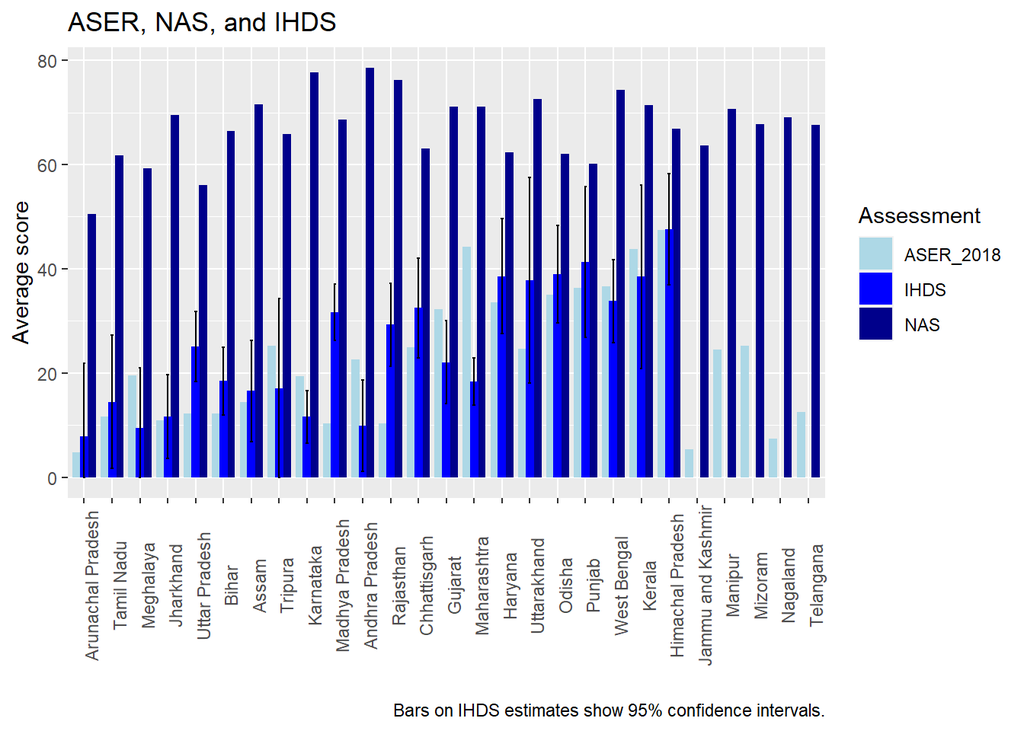

```r
# multiply se
scores.long2 <- scores.long2  %>%
  mutate(se = 100*se)


# create y_min and y_max
m <- qnorm(1-.05/2)
scores.long2 <- scores.long2  %>%
  mutate(ymin = avg_score-m*se, ymax = avg_score+m*se) %>%
  mutate(ymin = ifelse(ymin <0, 0, ymin))


ggplot(data = scores.long2, aes(x= reorder(State, avg_score),y=avg_score, fill= Assessment)) +
  geom_bar(stat = "identity", position = position_dodge(width=.8)) +
  geom_errorbar(aes(ymin = ymin, ymax = ymax), width = .1) +
  theme(axis.text.x = element_text(angle=90)) +
  scale_fill_manual(values = c("lightblue", "blue", "darkblue"))+
  labs(y = "Average score", x = "", title = "ASER, NAS, and IHDS", caption = "Bars on IHDS estimates show 95% confidence intervals.")
```

```r
ggsave("aser_nas_ihds_values.png", width = 9, height = 6 , path = figures)
```